# R Notebook

- name:LIU SHENG
- ID:3036424496

## Q1

In this exercise, we are going to use the Carseats data set. We will seek to predict Sales using regression trees and related approaches

### a

Split the data set into a training set and a test set

```r
library(tidyverse)
library(tidymodels)
Carseats<- read_csv("https://raw.githubusercontent.com/kwan-MSDA/MSDA7003/refs/heads/main/Carseats.csv")
Carseats<- Carseats %>%
  mutate_if(is.character, as.factor)

set.seed(123)
data_split <- initial_split(Carseats, prop = 0.7)
Carseats_train <- training(data_split)
Carseats_test <- testing(data_split)
```

### b

Fit a regression tree to the training set

```r
library(rpart)
Carseats_model <- rpart(Sales ~ ., data = Carseats_train, method = 'anova')
```

1.Plot the tree and interpret the results

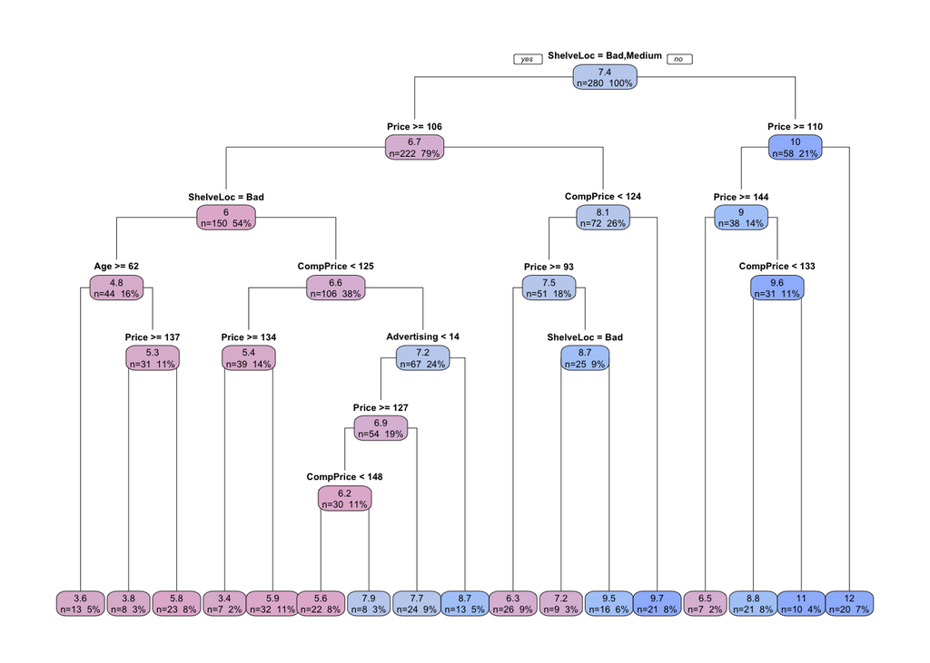

```r
library(rpart.plot)
pa_pal_2tone <- colorRampPalette(c("#DFBAD3", "#E6B8D4", "#BAD8F6", "#9FBBFC"))

Carseats_model %>%
  rpart.plot(
    roundint = FALSE,
    box.palette = pa_pal_2tone(6),
    type = 1,
    extra = 101,
    tweak = 1.1
  )
```

```r
# Make predictions on the test set
predictions <- predict(Carseats_model, new_data = Carseats_test)

# Calculate Mean Squared Error
test_mse <- mean((predictions - Carseats_test$Sales)^2)
print(paste("Test MSE:", round(test_mse, 3)))
```

```
## [1] "Test MSE: 13.409"
```

### answer

- The MSE I obtained is 13.409

### c

Use cost complexity to do pruning the tree (Hint: set cp at different value to prune the tree)

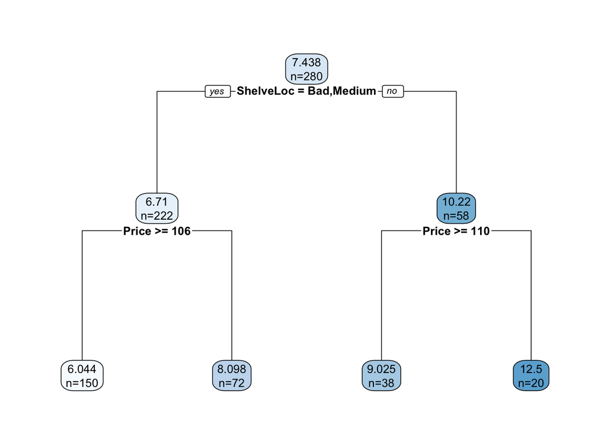

```r
prune<- Carseats_model %>%
  rpart::prune(cp=0.05)

prune %>% rpart.plot(extra=1, cex=0.8, digits=4)
```

- Does pruning the tree improve the test MSE?

```r
library(yardstick)
library(dplyr)

prune <- rpart::prune(Carseats_model, cp = 0.05)

# Make predictions on the test data
predictions <- predict(prune, newdata = Carseats_test)

test_mse <- mean((predictions - Carseats_test$Sales)^2)
print(paste("Test MSE:", round(test_mse, 3)))
```

```
## [1] "Test MSE: 4.979"
```

- (Bonus) Use cross-validation to determine the optimal level of tree complexity

```r
# Use cross-validation to find the optimal cp
printcp(Carseats_model)
```

```
##
## Regression tree:
## rpart(formula = Sales ~ ., data = Carseats_train, method = "anova")
##
## Variables actually used in tree construction:
## [1] Advertising Age         CompPrice   Price       ShelveLoc
##
## Root node error: 2227.2/280 = 7.9544
##
## n= 280
##
##          CP nsplit rel error  xerror     xstd
## 1  0.254622      0   1.00000 1.00742 0.084722
## 2  0.092152      1   0.74538 0.76140 0.059011
## 3  0.070902      2   0.65323 0.73872 0.058054
## 4  0.043245      3   0.58232 0.63047 0.048350
## 5  0.036049      4   0.53908 0.62552 0.050904
## 6  0.032271      5   0.50303 0.63451 0.052964
## 7  0.024286      7   0.43849 0.59448 0.048571
## 8  0.017482      8   0.41420 0.59106 0.048463
## 9  0.015915      9   0.39672 0.60713 0.052976
## 10 0.015626     10   0.38080 0.61605 0.053264
## 11 0.014133     11   0.36518 0.60544 0.052892
## 12 0.013544     12   0.35104 0.59908 0.052783
## 13 0.012653     14   0.32396 0.59610 0.052405
## 14 0.010461     15   0.31130 0.58343 0.051559
## 15 0.010000     16   0.30084 0.58139 0.051643
```

```r
optimal_cp <- Carseats_model$cptable[which.min(Carseats_model$cptable[, "xerror"]), "CP"]

# Prune the tree
pruned_tree <- rpart::prune(Carseats_model, cp = optimal_cp)

# Evaluate the pruned tree on the test set
pruned_predictions <- predict(pruned_tree, newdata = Carseats_test)
pruned_mse <- mean((pruned_predictions - Carseats_test$Sales)^2)
print(paste("Pruned Test MSE:", round(pruned_mse, 3)))
```

```
## [1] "Pruned Test MSE: 3.784"
```

### d

Use the bagging approach to analyse this data

```r
# Fit bagging model
library(randomForest)
#install.packages('randomForest')
set.seed(123)
bagging <- randomForest(Sales~., Carseats_train, mtry = 10, ntree = 500)
bagging
```

```
##
## Call:
##  randomForest(formula = Sales ~ ., data = Carseats_train, mtry = 10,      ntree = 500)
##                Type of random forest: regression
##                      Number of trees: 500
## No. of variables tried at each split: 10
##
##           Mean of squared residuals: 2.620843
##                     % Var explained: 67.05
```

- What test MSE do you obtain?

```r
bagging_predictions <- predict(bagging, newdata = Carseats_test)
bagging_mse <- mean((bagging_predictions - Carseats_test$Sales)^2)
print(paste("Bagging Test MSE:", round(bagging_mse, 3)))
```

```
## [1] "Bagging Test MSE: 2.307"
```

- Use the importance () function to determine which variables are most important

```r
importance(bagging)
```

```
##             IncNodePurity
## CompPrice      264.667285
## Income         113.628559
## Advertising    153.556067
## Population      62.515055
## Price          617.820503
## ShelveLoc      697.081817
## Age            178.707596
## Education       68.491233
## Urban            8.387530
## US               7.612992
```

### answer

- Price and ShelveLoc are most important

### e

Use random forests to analyse this data

- What test MSE do you obtain?
- Use the importance () function to determine which variables are most important
- Describe the effect of m, the number of variables considered at each split, on the error rate obtained

```r
# Fit random forest
set.seed(123)
#p=10--mtry=10/3
rf <- randomForest(Sales~., Carseats_train, mtry = 3, ntree = 500)
rf
```

```
##
## Call:
##  randomForest(formula = Sales ~ ., data = Carseats_train, mtry = 3,      ntree = 500)
##                Type of random forest: regression
##                      Number of trees: 500
## No. of variables tried at each split: 3
##
##           Mean of squared residuals: 2.980787
##                     % Var explained: 62.53
```

```r
# mes
rf_predictions <- predict(rf, newdata = Carseats_test)
rf_mse <- mean((rf_predictions - Carseats_test$Sales)^2)
print(paste("rf Test MSE:", round(rf_mse, 3)))
```

```
## [1] "rf Test MSE: 2.784"
```

```r
#
importance (rf)
```

```
##             IncNodePurity
## CompPrice       225.44105
## Income          161.49519
## Advertising     184.32987
## Population      126.82249
## Price           487.34464
## ShelveLoc       506.04902
## Age             264.20927
## Education       104.24594
## Urban            19.73498
## US               24.25848
```

### f

(Bonus) Analyse the data using boosting - What test MSE do you obtain?

```r
library(xgboost)
#install.packages('xgboost')

# Prepare data for xgboost
x_train <- model.matrix(Sales ~ . - 1, data = Carseats_train)
x_test <- model.matrix(Sales ~ . - 1, data = Carseats_test)
y_train <- Carseats_train$Sales
y_test <- Carseats_test$Sales

# Convert to xgb.DMatrix format
xgb_train <- xgb.DMatrix(data = x_train, label = y_train)
xgb_test <- xgb.DMatrix(data = x_test, label = y_test)

#
watchlist<- list(train=xgb_train, test=xgb_test)
#fit model
model<- xgb.train(data = xgb_train, max_depth = 2, eta = 0.1,
                  nrounds = 100,
                  watchlist = watchlist,
                  objective = "reg:squarederror",
                  eval_metric = "rmse")
a<- which.min(model$evaluation_log$test_rmse)

final<- xgboost(data = xgb_train, max_depth = 2, eta = 1,
                  verbose = 0,
                  nrounds = a,
                  objective = "reg:squarederror")
final
```

```
## ##### xgb.Booster
## raw: 91.1 Kb
## call:
##   xgb.train(params = params, data = dtrain, nrounds = nrounds,
##     watchlist = watchlist, verbose = verbose, print_every_n = print_every_n,
##     early_stopping_rounds = early_stopping_rounds, maximize = maximize,
##     save_period = save_period, save_name = save_name, xgb_model = xgb_model,
##     callbacks = callbacks, max_depth = 2, eta = 1, objective = "reg:squarederror")
## params (as set within xgb.train):
##   max_depth = "2", eta = "1", objective = "reg:squarederror", validate_parameters = "TRUE"
## xgb.attributes:
##   niter
## callbacks:
##   cb.evaluation.log()
## # of features: 12
## niter: 100
## nfeatures : 12
## evaluation_log:
##   iter train_rmse
##  <num>      <num>
##      1  2.1976844
##      2  1.9192612
##    ---        ---
##     99  0.2550413
##    100  0.2521366
```

```r
mean((predict(final, x_test)- y_test)^2)
```

```
## [1] 2.700324
```

### answer

- boosting Test MSE is 2.700324

## Q2

In this exercise, we will predict the number of applications received (Apps) using the other variables in the College data set. It contains several variables for 777 different universities and colleges in the US. The variables are

• Private: Public/private indicator

• Apps: Number of applications received

• Accept: Number of applicants accepted

• Enroll: Number of new students enrolled

• Top10perc: New students from top 10 % of high school class

• Top25perc: New students from top 25 % of high school class

• F.Undergrad: Number of full-time undergraduates

• P.Undergrad: Number of part-time undergraduates

• Outstate: Out-of-state tuition

• Room.Board: Room and board costs

• Books: Estimated book costs

• Personal: Estimated personal spending

• PhD: Percent of faculty with Ph.D.’s

• Terminal: Percent of faculty with terminal degree

• S.F.Ratio: Student/faculty ratio

• perc.alumni: Percent of alumni who donate

• Expend: Instructional expenditure per student

• Grad.Rate: Graduation rate

### a

Split the data set into a training set and a test set

• Hint: choose some numbers or proportion that you find appropriate))

```r
College<- read_csv("https://raw.githubusercontent.com/kwan-MSDA/MSDA7003/refs/heads/main/College.csv")
set.seed(1234)
#
College<- College %>%
  mutate_if(is.character, as.factor)
#
data_split <- initial_split(College, prop = 0.7)
College_train <- training(data_split)
College_test <- testing(data_split)
```

### b

Fit a linear model using least squares on the training set

• Report the test error obtained

```r
# Fit a linear regression model
lm.fit<- lm(Apps~., data = College_train)
# Compute the test MSE
lm.pred<- predict(lm.fit, College_test)
lm_test_MSE<- mean((lm.pred - College_test$Apps)^2)
print(paste("Test MSE:", round(lm_test_MSE, 2)))
```

```
## [1] "Test MSE: 826006.83"
```

### c

Fit a ridge regression model on the training set, with λ chosen by cross-validation.

• Report the test error obtained.

```r
#install.packages("glmnet")
library(glmnet)
```

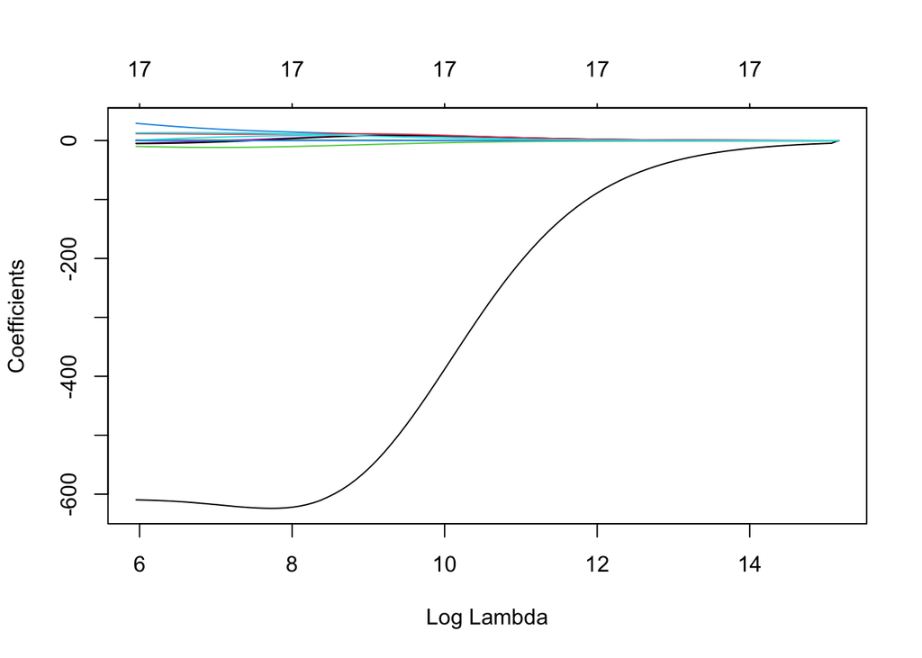

```r
library(tidyverse)
library(glmnet)

# Fit a ridge regression model
x<- model.matrix(Apps~., data = College_train)[,-1]
y<- College_train$Apps
ridge.fit<- glmnet(x, y, alpha = 0)
plot(ridge.fit, xvar = "lambda")
```

```r
cv.fit_ridge<- cv.glmnet(x, y, type.measure = "mse", nfolds = 10, alpha = 0)
ridge_cv.pred_min<- predict(cv.fit_ridge, s = cv.fit_ridge$lambda.min, newx = model.matrix(Apps~., data =College_test)[,-1])
cat("the mean square test error for min lambda" , mean((ridge_cv.pred_min - College_test$Apps)^2), "\n")
```

```
## the mean square test error for min lambda 849404.4
```

### d

Fit a lasso model on the training set, with λ chosen by cross-validation

• Report the test error obtained

• What is the number of non-zero coefficient estimates?

```r
lasso.fit<- glmnet(x, y, alpha = 1)
#plot(lasso.fit, xvar = "lambda")
# Perform cross-validation to select the optimal value of lambda
cv.fit_lasso<- cv.glmnet(x, y, alpha = 1, type.measure = "mse", nfolds = 10)
print(cv.fit_lasso)
```

```
##
## Call:  cv.glmnet(x = x, y = y, type.measure = "mse", nfolds = 10, alpha = 1)
##
## Measure: Mean-Squared Error
##
##     Lambda Index Measure     SE Nonzero
## min   17.5    59 1593280 467475      14
## 1se  498.0    23 2044591 686159       2
```

```r
#
lasso_cv.pred_min<- predict(cv.fit_lasso, s = cv.fit_lasso$lambda.min, newx = model.matrix(Apps~., data = College_test)[,-1])
cat("the mean square test error for min lambda LASSO is" , mean((lasso_cv.pred_min - College_test$Apps)^2), "\n")
```

```
## the mean square test error for min lambda LASSO is 781613.1
```

## Q3

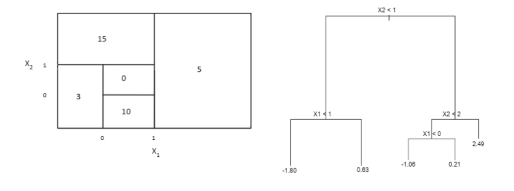

The above two graphs report the results of two (different) regression trees.

### a

Sketch the tree corresponding to the partition of the predictor space illustrated in the left-hand panel of the above figure (The numbers inside the boxes indicate the mean of Y within each region)

1. $X_1 \geq 1 : Y = 5$ (this overrides any other condition).
2. $X_2 \geq 1 : Y = 15$ (when $X_1 < 1$).
3. $X_1 < 0 : Y = 3$.
4. $X_1 \geq 0 \text{ and } X_2 < 0 : Y = 10$.
5. $X_1 \geq 0 \text{ and } X_2 \geq 0 : Y = 0$.

### b

Create a diagram like the left-hand panel of the above figure, using the tree illustrated in the right-hand panel of the same figure (hint: You should divide up the predictor space into the correct regions, and indicate the mean for each region)

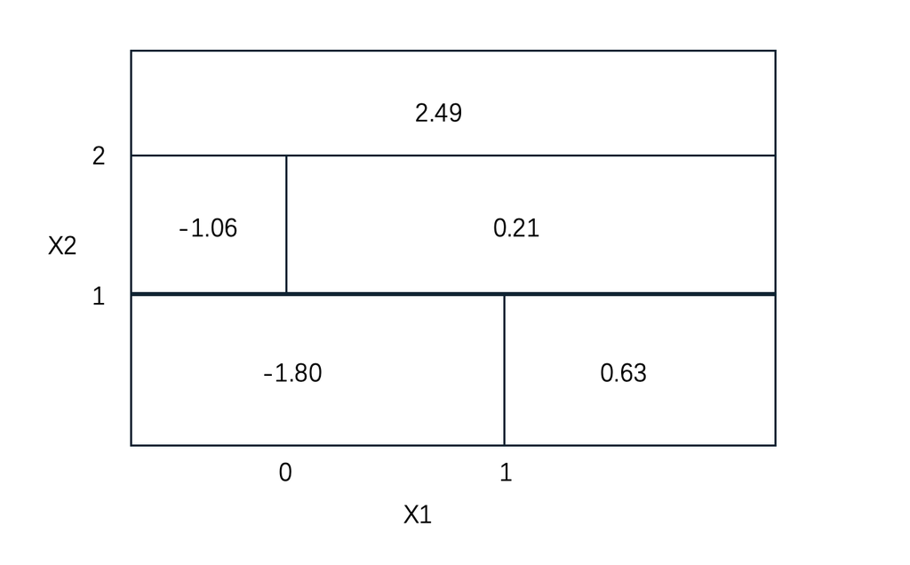